# Aula 12: Funções em R

# Funções em R

As estruturas de programação, como controle de fluxo e repetição, formam a base das linguagens de programação. No entanto, as funções representam um nível mais avançado e são um dos principais motivos pelos quais as linguagens de programação são tão poderosas e flexíveis.

## O que é uma Função?

As funções são blocos de código que recebem valores de **entrada** e geram valores de **saída** conforme as instruções implementadas. Elas encapsulam tarefas que podem ser compostas de várias instruções, permitindo o **reuso** de código de maneira enxuta e eficiente.

### Benefícios das Funções

- **Encapsulamento**: Agrupam várias instruções em um bloco lógico.
- **Reutilização de Código**: Evitam a repetição de código, permitindo que você chame a função sempre que precisar realizar a mesma tarefa.
- **Isolamento de Variáveis**: Preservam o estado das variáveis na área de trabalho, não alterando o estado das variáveis externas à função.

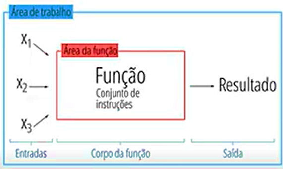

Funções

## Anatomia de uma Função

Vamos ver a anatomia de uma função na linguagem R.

Aqui está um exemplo de código mostrando a estruturação de uma função no R, semelhante ao exemplo de estrutura `repeat`:

```r
minha_funcao <- function(param1, param2) {
  # Passo 1: Realiza um procedimento inicial com os parâmetros
  resultado_inicial <- param1 + param2  # Procedimento inicial

  if (resultado_inicial > 10) {
    return("Resultado maior que 10, função encerrada.")  # Condição de retorno antecipado (early return)
  }

  # Passo 2: Realiza um procedimento intermediário
  resultado_intermediario <- resultado_inicial * 2  # Procedimento intermediário

  if (resultado_intermediario > 20) {
    resultado_intermediario <- resultado_intermediario / 2  # Ajusta o resultado se necessário
  }

  # Passo 3: Realiza um procedimento final e retorna o resultado
  resultado_final <- resultado_intermediario + 5  # Procedimento final
  return(resultado_final)  # Retorno da função
}

# Chamando a função com diferentes parâmetros
resultado1 <- minha_funcao(3, 4)
print(resultado1)  # Resultado esperado: 19

resultado2 <- minha_funcao(8, 5)
print(resultado2)  # Resultado esperado: "Resultado maior que 10, função encerrada."
```

- **minha_funcao**: O nome da função que será usada para chamá-la.
- **param1, param2**: Os parâmetros da função que recebem os valores de entrada.
- **Passo 1**: Realiza um procedimento inicial, como somar os parâmetros. Se o resultado for maior que 10, a função retorna imediatamente com uma mensagem.
- **Passo 2**: Se a função não for encerrada no primeiro passo, ela continua e realiza um procedimento intermediário, como multiplicar o resultado inicial por 2.
- **Passo 3**: Realiza um procedimento final e retorna o resultado final da função.

Este exemplo mostra como você pode estruturar uma função no R com diferentes etapas, condições de saída antecipadas, e um retorno final.

### Componentes de uma Função

1. **Nome da Função**: Usado para chamá-la.
2. **Lista de Parâmetros**: Também conhecida como lista de argumentos formais, que recebe os valores de entrada.
3. **Corpo da Função**: Contém a série de instruções que são realizadas.
4. **Retorno da Função**: Retorna o resultado que a função gerou após a execução das instruções.

```r
resultado2
```

[output not shown]

### Contextualizando o Cálculo da Área de um Triângulo

$$\text{Área} = \frac{b \times h}{2}$$

No entanto, podemos usar coordenadas para calcular a área de um triângulo irregular usando a fórmula de Shoelace.

```
[1] 2
```

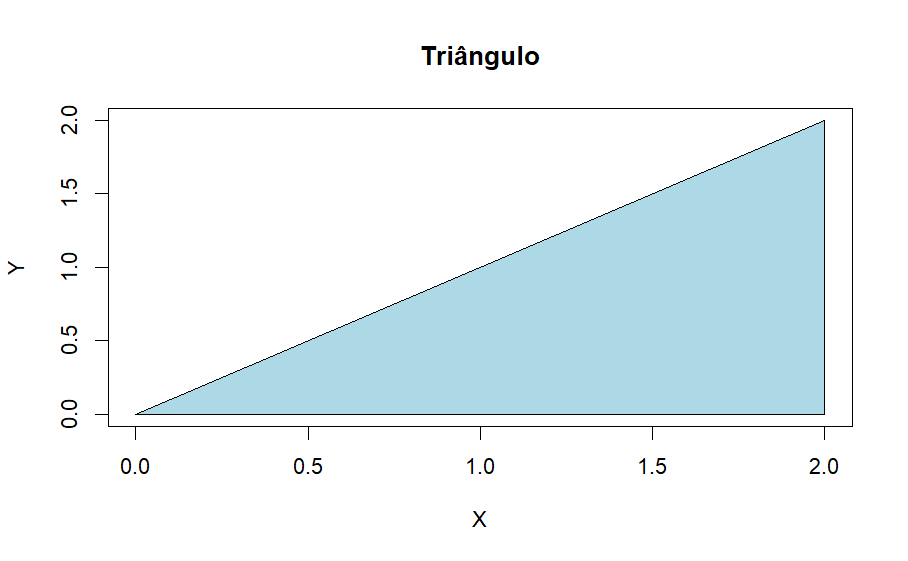

```r
calc_area(X2)
```

### Exemplo: Fórmula de Bhaskara

$$ax^2 + bx + c = 0$$

O discriminante ($\Delta$) é calculado como:

$$\Delta = b^2 - 4ac$$

As raízes da equação são dadas por:

$$x = \frac{-b \pm \sqrt{\Delta}}{2a}$$

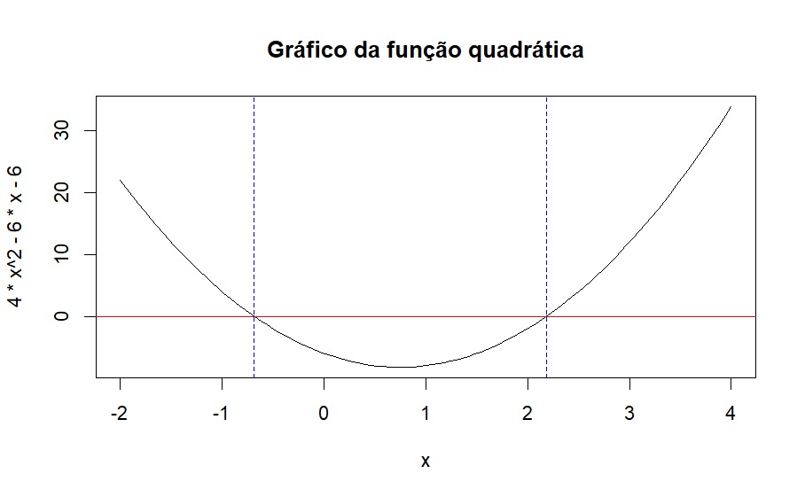